# Gresham Lab Flow Core Guide

zed

2016-11-23

> “I hear and I forget. I see and I remember. I copy this file and modify it and I have a reproducible record of my analyses.”
> - Confucious

**Experiment overview**

For example, this example without context makes me wonder why we’re looking for GFP fluoresence with a dye as the major source of variation in the experimental design. Is there a GFP as a transcription-and-translation reporter of dye content?

> This code is designed for use with the Accuri flow cytometer, which is equiped with the following lasers and filters
- Blue laser (488 nm)
- FL1 filter = 514/20nm GFP
- FL3 filter = 575/25nm YFP
- Yellow/green laser (552 nm)
- FL2 filter = 610/20nm mCherry, dtomato
- FL4 filter = 586/15nm DsRed

[You should be familiar with your flow cytometer](https://gencore.bio.nyu.edu/shared-equipment/flow-cytometry/)

**Output**  
This script generates a summary of results followed by quality control plots.

# 1 Step 1: Load relevant libraries

This is a function that just makes sure you have a package, or installs it for you without prompting

```r
source("src/requireInstall.R")
requireInstall("reshape2")
```

```
## [1] 1
```

```r
requireInstall("ggplot2")
```

```
## [1] 1
```

```r
requireInstall("flowCore",isBioconductor=T)
```

```
## [1] 1
```

```r
requireInstall("flowViz",isBioconductor=T)
```

```
## [1] 1
```

```r
requireInstall("Hmisc",isBioconductor=T)
```

```
## [1] 1
```

```r
requireInstall("gridExtra")
```

```
## [1] 1
```

```r
requireInstall("flowStats",isBioconductor=T)
```

```
## [1] 1
```

```r
requireInstall("flowWorkspace",isBioconductor=T)
```

```
## [1] 1
```

```r
requireInstall("ggcyto", isBioconductor=T)
```

```
## [1] 1
```

# 2 Step 2: Read in .fcs files

Read in all data for analysis. Data should be in individual directories that contain .fcs files and a corresponding sample sheet with a generic format. FCS file names need to match the `SampleSheet.txt`.

Want to make your `SampleSheet.txt`? Use a GUI spreadsheet thingy, like excel or googledocs or localc or `edit()` in R. The format is:

| FileName | Ploidy | Dye | … |
| --- | --- | --- | --- |
| A01.fcs | 1.5ploid | acridineOrange | … |
| A02 | 2.5ploid | acridineOrange | … |
| A03.fcs | 1.5ploid | sytoselect | … |

Where the only mandatory variable name is `FileName`, then all the others are whatever you’re using.

An abitrary number of directories can be used, put the paths in the `dataDirectoryz` vector. Here we use relative becuase it should be reproducible between users. You should use ABSOLUTE for your real work. Don’t have this folder? Download it (look up).

```r
dataDirectoryz <- c("exampleFlowDataset1")

rm(oneBigFlowSet)
for (dataDirectory in dataDirectoryz) {

  print(paste("Reading",dataDirectory))

  tmpSampleSheet <- read.delim(
    paste0(dataDirectory,"/SampleSheet.txt"),row.names=1)

  tmpFlowSet <- read.flowSet(path=dataDirectory,pattern=".fcs",
    alter.names=TRUE, #why?
    phenoData=new("AnnotatedDataFrame",data=tmpSampleSheet))

  sampleNames(tmpFlowSet) <- paste0(dataDirectory,"/",
    sampleNames(tmpFlowSet))
  pData(tmpFlowSet)$name <- sampleNames(tmpFlowSet)

  if (exists("oneBigFlowSet")) {
    oneBigFlowSet <- rbind2(oneBigFlowSet,tmpFlowSet)
  } else {
    oneBigFlowSet <- tmpFlowSet
  }
}
```

```
## [1] "Reading exampleFlowDataset1"
```

```r
pData(oneBigFlowSet)
```

```
##                             Strain ul500nMDye Ploidy      Media Expierment
## exampleFlowDataset1/A01.fcs   DGY1          0     1N C-lim-D0.3      expt1
## exampleFlowDataset1/A02.fcs   DGY1         10     1N C-lim-D0.3      expt1
## exampleFlowDataset1/A03.fcs   DGY1         50     1N C-lim-D0.3      expt1
## exampleFlowDataset1/A04.fcs   DGY1        100     1N C-lim-D0.3      expt1
## exampleFlowDataset1/A05.fcs   DGY1        250     1N C-lim-D0.3      expt1
## exampleFlowDataset1/A06.fcs   DGY1        500     1N C-lim-D0.3      expt1
##                                                    name
## exampleFlowDataset1/A01.fcs exampleFlowDataset1/A01.fcs
## exampleFlowDataset1/A02.fcs exampleFlowDataset1/A02.fcs
## exampleFlowDataset1/A03.fcs exampleFlowDataset1/A03.fcs
## exampleFlowDataset1/A04.fcs exampleFlowDataset1/A04.fcs
## exampleFlowDataset1/A05.fcs exampleFlowDataset1/A05.fcs
## exampleFlowDataset1/A06.fcs exampleFlowDataset1/A06.fcs
```

```r
print("Counted this many events:")
```

```
## [1] "Counted this many events:"
```

```r
print(fsApply(oneBigFlowSet,nrow))
```

```
##                              [,1]
## exampleFlowDataset1/A01.fcs 50000
## exampleFlowDataset1/A02.fcs 50000
## exampleFlowDataset1/A03.fcs 50000
## exampleFlowDataset1/A04.fcs 50000
## exampleFlowDataset1/A05.fcs 50000
## exampleFlowDataset1/A06.fcs 50000
```

```r
print("other statz?")
```

```
## [1] "other statz?"
```

```r
print(fsApply(oneBigFlowSet,each_col,median))
```

```
##                                FSC.A   SSC.A   FL1.A FL2.A FL3.A FL4.A
## exampleFlowDataset1/A01.fcs 562697.0 77701.0  2566.0   276   756   251
## exampleFlowDataset1/A02.fcs 637355.5 90199.5  9941.0   558  2242   493
## exampleFlowDataset1/A03.fcs 579237.0 79793.0 19631.0  1146  4984  1002
## exampleFlowDataset1/A04.fcs 546466.0 80743.0 20697.5  1267  5452  1090
## exampleFlowDataset1/A05.fcs 552799.5 81623.0 25457.0  1641  7192  1423
## exampleFlowDataset1/A06.fcs 524191.5 78656.0 28496.5  1862  8128  1614
##                                FSC.H    SSC.H   FL1.H FL2.H FL3.H FL4.H
## exampleFlowDataset1/A01.fcs 871409.5 108347.0  2846.0   185  1594   421
## exampleFlowDataset1/A02.fcs 969225.0 122714.5  9728.0   419  2453   568
## exampleFlowDataset1/A03.fcs 898238.0 110155.0 18645.0   953  4677   959
## exampleFlowDataset1/A04.fcs 852802.0 113254.0 19810.0  1077  5120  1042
## exampleFlowDataset1/A05.fcs 859692.0 114994.5 24078.0  1412  6609  1328
## exampleFlowDataset1/A06.fcs 820285.5 111785.0 27025.5  1616  7456  1508
##                             Width Time
## exampleFlowDataset1/A01.fcs    58  184
## exampleFlowDataset1/A02.fcs    60  184
## exampleFlowDataset1/A03.fcs    58  188
## exampleFlowDataset1/A04.fcs    57  184
## exampleFlowDataset1/A05.fcs    58  186
## exampleFlowDataset1/A06.fcs    57  188
```

```r
save(file=paste0("flowSet",digest::digest(oneBigFlowSet),".RData"))
```

Now you have `oneBigFlowSet`. Great. For gating, we’ll turn that into a data.frame:

```r
source("src/fs2df.R")
datar <- fs2df(oneBigFlowSet)
```

# 3 Step 3: gate

So I can’t actually figure out how to make rmarkdown play with interactive chunks. So you should see an error right about….

```r
gateFilename <- paste0("gatesFor",digest::digest(oneBigFlowSet),".RData")
load(gateFilename)
```

Okay, so now go to your terminal and run this:

```r
source("src/gator.R")
gatez <- list()
gatez[["singlet"]] <- gator2d(datar,ehx="FSC.A",why="FSC.H",
  gateName="singlet")
gatez[["cells"]] <- gator2d(datar,ehx="FSC.A",why="SSC.A",
  gateName="cells")
gatez[["gfpPos"]] <- gator2d(datar,ehx="FSC.A",why="FL1.A",
  gateName="gfpPositive")
gatez[["gfpNeg"]] <- gator2d(datar,ehx="FSC.A",why="FL1.A",
  gateName="gfpDepressing")
save(file=gateFilename,list=c("gatez"))
```

If you screw it up, delete the RData file of the gates, and re-run.

how they look?

```
## [1] "singlet"
```

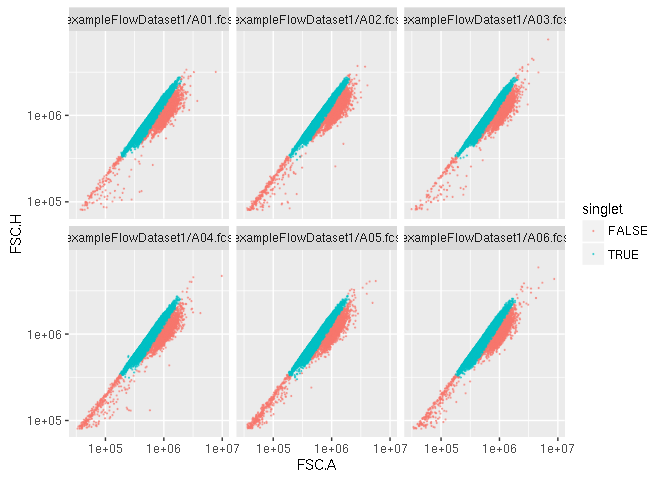

```
## [1] "cells"
```

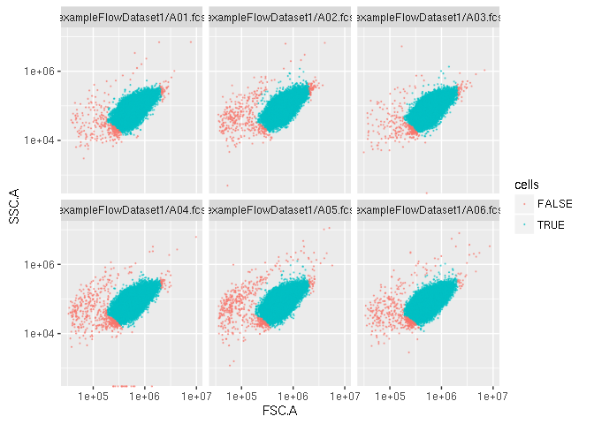

```
## [1] "gfpPos"
```

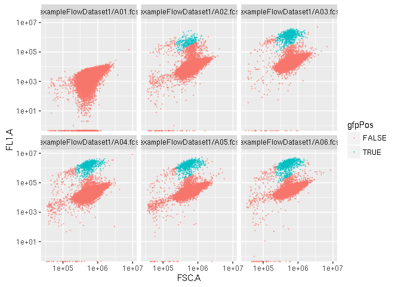

```
## [1] "gfpNeg"
```

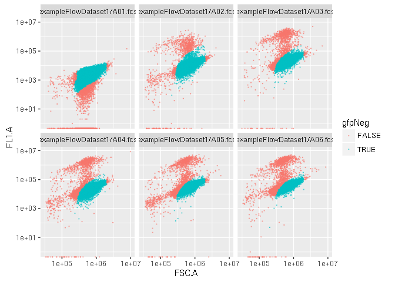

```r
#source("src/gateCheck.R")
#gateCheck()
#make a function so we can re-call it after starting to apply these
for (gateName in names(gatez)) {
  print(gateName)
  ingate  <- data.frame(
    fs2df(Subset(oneBigFlowSet,gatez[[gateName]])),thisGate=T)
  outgate <- data.frame(
    fs2df(Subset(oneBigFlowSet,!gatez[[gateName]])),thisGate=F)
  shuffle <- rbind(ingate,outgate)
  shuffle <- shuffle[sample(1:nrow(shuffle)),]
  names(shuffle)[which(names(shuffle)=="thisGate")] <- gateName
  print(
    ggplot(shuffle)+
      facet_wrap(~name)+
      aes_string(x=colnames(gatez[[gateName]]@boundaries)[1],
                 y=colnames(gatez[[gateName]]@boundaries)[2],
                 col=gateName)+
      geom_point(size=0.2,alpha=0.5)+
      scale_y_log10()+
      scale_x_log10()
  )
}
```

Subset the data by applying sequential gates

> “When you have doublets, do not fear to abandon them.”
> - Confucious

```r
rm(filteredDatar)
for (gateName in c("singlet","cells")) {
  print(gateName)
  if (exists("filteredDatar")) {
    filteredDatar  <- Subset(filteredDatar,gatez[[gateName]])
  } else {
    filteredDatar  <- Subset(oneBigFlowSet,gatez[[gateName]])
  }
}
```

```
## [1] "singlet"
## [1] "cells"
```

```r
#gateCheck() call would go here
```

Buidling a better datastructure, for later use

```r
source("src/splitFSbyGate.R")
gatedFilteredDatar <- filteredDatar
for (gateName in setdiff(names(gatez),c("singlet","cells"))) {
  gatedFilteredDatar <- splitFSbyGate(gatedFilteredDatar,
    gatez[[gateName]])
}
```

```
## [1] "applying gate gfpPos"
## [1] "applying gate gfpNeg"
```

```r
gfdatar <- fs2df(gatedFilteredDatar)
```

# 4 Step 4: Plotz

Into usable form:

```r
head(gfdatar)
```

```
##   Strain ul500nMDye Ploidy      Media Expierment
## 1   DGY1          0     1N C-lim-D0.3      expt1
## 2   DGY1          0     1N C-lim-D0.3      expt1
## 3   DGY1          0     1N C-lim-D0.3      expt1
## 4   DGY1          0     1N C-lim-D0.3      expt1
## 5   DGY1          0     1N C-lim-D0.3      expt1
## 6   DGY1          0     1N C-lim-D0.3      expt1
##                          name gfpPos gfpNeg  FSC.A  SSC.A FL1.A FL2.A
## 1 exampleFlowDataset1/A01.fcs  FALSE   TRUE 652669 144896  2548   397
## 2 exampleFlowDataset1/A01.fcs  FALSE   TRUE 710736  56184  1846    91
## 3 exampleFlowDataset1/A01.fcs  FALSE   TRUE 373277  23843  1543   188
## 4 exampleFlowDataset1/A01.fcs  FALSE   TRUE 448538  71085  1581   278
## 5 exampleFlowDataset1/A01.fcs  FALSE   TRUE 500382 105385  2809   219
## 6 exampleFlowDataset1/A01.fcs  FALSE   TRUE 888546 138845  6934   444
##   FL3.A FL4.A   FSC.H  SSC.H FL1.H FL2.H FL3.H FL4.H Width Time
## 1  2244     0  887408 179410  2551   205  2277   431    64  140
## 2  1655   345 1208942  82023  2788   115  2127   359    56  140
## 3  2505     0  634903  43165  1842   106  1464    42    51  140
## 4   510   532  739700 101710  2436   137  1966   443    52  140
## 5  1015   283  834475 149330  1872   329  2045   502    54  140
## 6  1434   729 1396656 187847  6291   242  1179   620    63  140
```

```r
mfdatar <- melt(gfdatar,
  id.vars=c("Strain","ul500nMDye","Ploidy","Media","name","gfpPos","gfpNeg"),
  measure.vars=c("FSC.A","FSC.H","FL1.A","FL1.H","FL2.A","FL2.H"))
head(mfdatar)
```

```
##   Strain ul500nMDye Ploidy      Media                        name gfpPos
## 1   DGY1          0     1N C-lim-D0.3 exampleFlowDataset1/A01.fcs  FALSE
## 2   DGY1          0     1N C-lim-D0.3 exampleFlowDataset1/A01.fcs  FALSE
## 3   DGY1          0     1N C-lim-D0.3 exampleFlowDataset1/A01.fcs  FALSE
## 4   DGY1          0     1N C-lim-D0.3 exampleFlowDataset1/A01.fcs  FALSE
## 5   DGY1          0     1N C-lim-D0.3 exampleFlowDataset1/A01.fcs  FALSE
## 6   DGY1          0     1N C-lim-D0.3 exampleFlowDataset1/A01.fcs  FALSE
##   gfpNeg variable  value
## 1   TRUE    FSC.A 652669
## 2   TRUE    FSC.A 710736
## 3   TRUE    FSC.A 373277
## 4   TRUE    FSC.A 448538
## 5   TRUE    FSC.A 500382
## 6   TRUE    FSC.A 888546
```

- summary statistics

Many of the `gatedFilteredDatar` things will be `NA`’s, that’s ok. It’s because there’s not many members in those particular gate/flowframes.

```r
fsApply(filteredDatar,function(x){
  data.frame(t(each_col(x,summary)))})
```

```
## $`exampleFlowDataset1/A01.fcs`
##         Min. X1st.Qu. Median      Mean X3rd.Qu.    Max.
## FSC.A 191500   448100 554900 584700.00   689200 1970000
## SSC.A  14300    57180  76160  82270.00   102200  437700
## FL1.A      0     1558   2515   2650.00     3591   13840
## FL2.A      0      107    274    293.40      446    1451
## FL3.A      0        0    741    947.80     1565    6174
## FL4.A      0        0    249    313.10      510    2316
## FSC.H 329200   712500 867800 910000.00  1060000 2751000
## SSC.H  19210    81290 107100 113600.00   139600  564100
## FL1.H      0     2014   2815   2989.00     3780   15090
## FL2.H      0      116    184    189.30      257     914
## FL3.H      0     1156   1582   1620.00     2043    5759
## FL4.H      0      279    418    436.00      572    2196
## Width     39       54     58     57.73       62     104
## Time     140      162    184    184.20      206     228
##
## $`exampleFlowDataset1/A02.fcs`
##         Min. X1st.Qu. Median      Mean X3rd.Qu.    Max.
## FSC.A 191400   507700 627700 6.558e+05   773100 1978000
## SSC.A  17230    66730  88050 9.472e+04   116400  878000
## FL1.A      0     7298   9721 1.424e+04    12470 2768000
## FL2.A      0      349    546 7.294e+02      754  171800
## FL3.A      0     1253   2184 3.105e+03     3174  840300
## FL4.A      0      201    481 6.521e+02      777  138800
## FSC.H 306000   798000 965000 1.005e+06  1171000 2740000
## SSC.H  20830    92960 120800 1.279e+05   155300 1169000
## FL1.H    133     7379   9601 1.397e+04    12120 2750000
## FL2.H      0      301    413 5.952e+02      538  167400
## FL3.H      0     1852   2423 3.338e+03     3104  824200
## FL4.H      0      396    560 7.205e+02      758  134200
## Width     41       55     59 5.942e+01       63      99
## Time     141      162    184 1.841e+02      206     228
##
## $`exampleFlowDataset1/A03.fcs`
##         Min. X1st.Qu. Median      Mean X3rd.Qu.    Max.
## FSC.A 187900   461300 571600 600800.00   706400 1997000
## SSC.A  13150    58260  78300  84360.00   104500  424900
## FL1.A      0    14800  19290  40790.00    24730 3961000
## FL2.A      0      835   1125   2184.00     1473  221000
```

[output cut: 46 more lines]

```
##         Min. X1st.Qu. Median      Mean X3rd.Qu.    Max.
## FSC.A 190300   416600 518400 549300.00   648300 1846000
## SSC.A  11790    56870  77210  83960.00   105100  480000
## FL1.A      0    21810  28080  63780.00    35890 4795000
## FL2.A      0     1414   1832   4175.00     2351 1090000
## FL3.A      0     6057   7995  17880.00    10320 1276000
## FL4.A      0     1131   1585   3463.00     2110 1467000
## FSC.H 314200   670200 817000 862600.00  1006000 2562000
## SSC.H  19420    83320 110600 117700.00   145200  689100
## FL1.H     68    21420  26780  61580.00    32970 4422000
## FL2.H      0     1260   1600   3849.00     1997  586900
## FL3.H      0     5810   7391  16980.00     9222 1257000
## FL4.H      0     1115   1493   3280.00     1933  782200
## Width     40       52     56     56.47       60     114
## Time     142      165    188    188.00      211     234
```

```r
fsApply(gatedFilteredDatar,function(x){
  data.frame(t(each_col(x,summary)))})
```

```
## $`exampleFlowDataset1/A01.fcs_in_gfpPos_in_gfpNeg`
##       Min. X1st.Qu. Median Mean X3rd.Qu. Max.
## FSC.A   NA       NA     NA  NaN       NA   NA
## SSC.A   NA       NA     NA  NaN       NA   NA
## FL1.A   NA       NA     NA  NaN       NA   NA
## FL2.A   NA       NA     NA  NaN       NA   NA
## FL3.A   NA       NA     NA  NaN       NA   NA
## FL4.A   NA       NA     NA  NaN       NA   NA
## FSC.H   NA       NA     NA  NaN       NA   NA
## SSC.H   NA       NA     NA  NaN       NA   NA
## FL1.H   NA       NA     NA  NaN       NA   NA
## FL2.H   NA       NA     NA  NaN       NA   NA
## FL3.H   NA       NA     NA  NaN       NA   NA
## FL4.H   NA       NA     NA  NaN       NA   NA
## Width   NA       NA     NA  NaN       NA   NA
## Time    NA       NA     NA  NaN       NA   NA
##
## $`exampleFlowDataset1/A02.fcs_in_gfpPos_in_gfpNeg`
##       Min. X1st.Qu. Median Mean X3rd.Qu. Max.
## FSC.A   NA       NA     NA  NaN       NA   NA
## SSC.A   NA       NA     NA  NaN       NA   NA
## FL1.A   NA       NA     NA  NaN       NA   NA
## FL2.A   NA       NA     NA  NaN       NA   NA
## FL3.A   NA       NA     NA  NaN       NA   NA
## FL4.A   NA       NA     NA  NaN       NA   NA
## FSC.H   NA       NA     NA  NaN       NA   NA
## SSC.H   NA       NA     NA  NaN       NA   NA
## FL1.H   NA       NA     NA  NaN       NA   NA
## FL2.H   NA       NA     NA  NaN       NA   NA
## FL3.H   NA       NA     NA  NaN       NA   NA
## FL4.H   NA       NA     NA  NaN       NA   NA
## Width   NA       NA     NA  NaN       NA   NA
## Time    NA       NA     NA  NaN       NA   NA
##
## $`exampleFlowDataset1/A03.fcs_in_gfpPos_in_gfpNeg`
##       Min. X1st.Qu. Median Mean X3rd.Qu. Max.
## FSC.A   NA       NA     NA  NaN       NA   NA
## SSC.A   NA       NA     NA  NaN       NA   NA
## FL1.A   NA       NA     NA  NaN       NA   NA
## FL2.A   NA       NA     NA  NaN       NA   NA
```

[output cut: 352 more lines]

```
##         Min. X1st.Qu. Median      Mean X3rd.Qu.    Max.
## FSC.A 190300   303500 338300 346800.00   379000 1099000
## SSC.A  17770    44430  60100  67560.00    83790  480000
## FL1.A      0    17050  21550  28050.00    30160 1780000
## FL2.A      0     1131   1457   1827.00     1946  238500
## FL3.A      0     4824   6259   7757.00     8632  516500
## FL4.A      0      886   1275   1587.00     1764  316000
## FSC.H 314200   512300 559300 565200.00   608600 1718000
## SSC.H  26780    67940  90600  97570.00   119600  689100
## FL1.H     68    17280  21400  26510.00    27270 1649000
## FL2.H      0     1015   1276   1578.00     1635  189000
## FL3.H      0     4734   6051   7173.00     7707  478000
## FL4.H      0      916   1233   1499.00     1622  243300
## Width     40       47     49     50.19       52      70
## Time     142      157    179    181.90      204     234
```

- for each sample plot a histogram of the normalized data, raw FSC and raw GFP per row

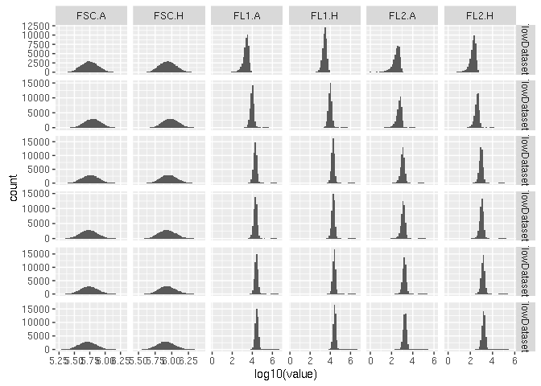

```r
ggplot(mfdatar)+
  facet_grid(name~variable,scales="free")+
  aes(x=log10(value))+
  geom_histogram(bins=50)
```

- extract data from flowFrames to plot histograms of values and record summary statistics

```r
aggregate(data=mfdatar,value~variable+name,FUN=mean)
```

```
##    variable                        name        value
## 1     FSC.A exampleFlowDataset1/A01.fcs  584736.4211
## 2     FSC.H exampleFlowDataset1/A01.fcs  910002.0923
## 3     FL1.A exampleFlowDataset1/A01.fcs    2649.5941
## 4     FL1.H exampleFlowDataset1/A01.fcs    2989.4792
## 5     FL2.A exampleFlowDataset1/A01.fcs     293.3694
## 6     FL2.H exampleFlowDataset1/A01.fcs     189.2957
## 7     FSC.A exampleFlowDataset1/A02.fcs  655795.7071
## 8     FSC.H exampleFlowDataset1/A02.fcs 1004570.9965
## 9     FL1.A exampleFlowDataset1/A02.fcs   14236.0950
## 10    FL1.H exampleFlowDataset1/A02.fcs   13972.8792
## 11    FL2.A exampleFlowDataset1/A02.fcs     729.4060
## 12    FL2.H exampleFlowDataset1/A02.fcs     595.2483
## 13    FSC.A exampleFlowDataset1/A03.fcs  600834.8675
## 14    FSC.H exampleFlowDataset1/A03.fcs  937561.7976
```

[output cut: 22 more lines]

```r
aggregate(data=mfdatar,value~variable+name,FUN=median)
```

```
##    variable                        name    value
## 1     FSC.A exampleFlowDataset1/A01.fcs 554931.0
## 2     FSC.H exampleFlowDataset1/A01.fcs 867794.0
## 3     FL1.A exampleFlowDataset1/A01.fcs   2515.0
## 4     FL1.H exampleFlowDataset1/A01.fcs   2815.0
## 5     FL2.A exampleFlowDataset1/A01.fcs    274.0
## 6     FL2.H exampleFlowDataset1/A01.fcs    184.0
## 7     FSC.A exampleFlowDataset1/A02.fcs 627654.0
## 8     FSC.H exampleFlowDataset1/A02.fcs 965042.0
## 9     FL1.A exampleFlowDataset1/A02.fcs   9721.0
## 10    FL1.H exampleFlowDataset1/A02.fcs   9601.0
## 11    FL2.A exampleFlowDataset1/A02.fcs    546.0
## 12    FL2.H exampleFlowDataset1/A02.fcs    413.0
## 13    FSC.A exampleFlowDataset1/A03.fcs 571620.0
## 14    FSC.H exampleFlowDataset1/A03.fcs 894066.0
```

[output cut: 22 more lines]

Specific plotz

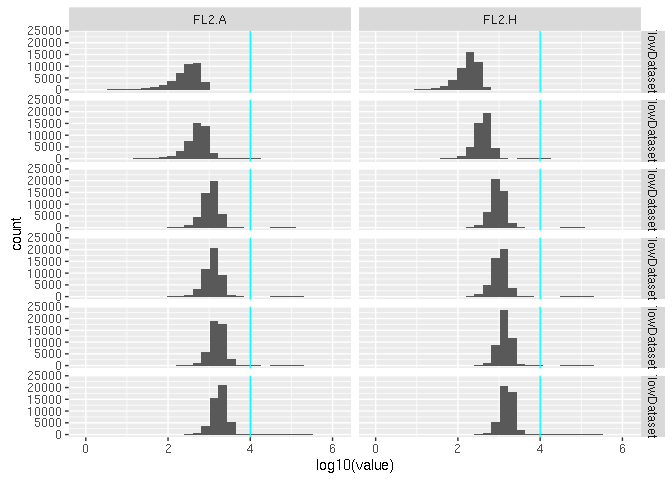

```r
ggplot(subset(mfdatar,variable%in%c("FL2.A","FL2.H")))+
  aes(x=log10(value))+facet_grid(name~variable)+
  geom_histogram()+
  geom_vline(xintercept=4,col="cyan")
```

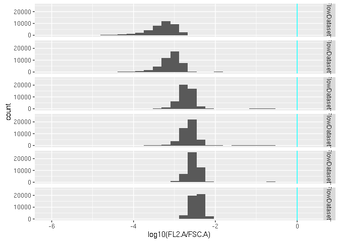

```r
ggplot(subset(gfdatar))+
  aes(x=log10(FL2.A/FSC.A))+
  facet_grid(name~.)+
  geom_histogram()+
  geom_vline(xintercept=0,col="cyan")
```

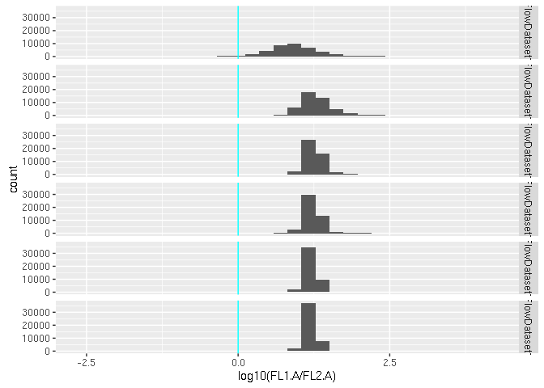

```r
ggplot(subset(gfdatar))+
  aes(x=log10(FL1.A/FL2.A))+
  facet_grid(name~.)+
  geom_histogram()+
  geom_vline(xintercept=0,col="cyan")
```

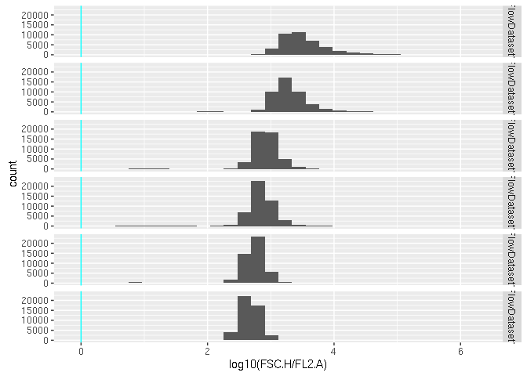

```r
ggplot(subset(gfdatar))+
  aes(x=log10(FSC.H/FL2.A))+
  facet_grid(name~.)+
  geom_histogram()+
  geom_vline(xintercept=0,col="cyan")
```

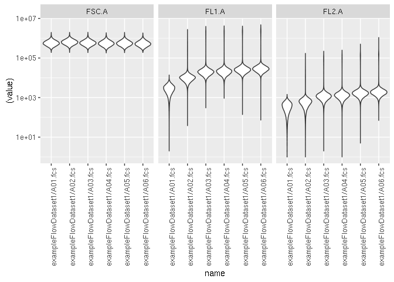

```r
ggplot(subset(mfdatar,variable%in%c("FSC.A","FL1.A","FL2.A")))+
  aes(x=name,y=(value))+facet_grid(~variable,scales="free")+
  geom_violin()+scale_y_log10()+
  theme(axis.text.x=element_text(angle=90))
```

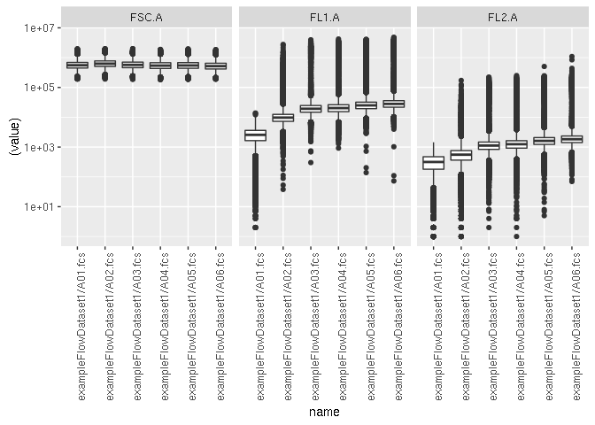

```r
ggplot(subset(mfdatar,variable%in%c("FSC.A","FL1.A","FL2.A")))+
  aes(x=name,y=(value))+facet_grid(~variable,scales="free")+
  geom_boxplot()+scale_y_log10()+
  theme(axis.text.x=element_text(angle=90))
```

Comparison of FL1.A to 0nM

```r
aggregate(data=gfdatar,FL1.A~ul500nMDye,FUN=median)
```

```
##   ul500nMDye FL1.A
## 1          0  2515
## 2         10  9721
## 3         50 19287
## 4        100 20344
## 5        250 25054
## 6        500 28078
```

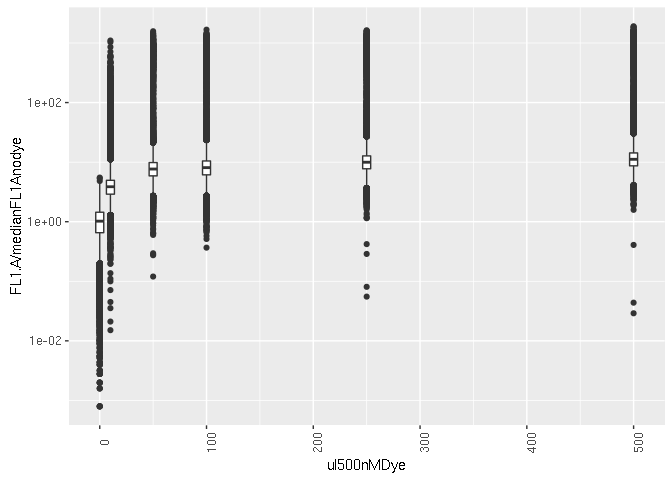

```r
medianFL1Anodye <- median(subset(gfdatar,ul500nMDye==0)$FL1.A)
ggplot(gfdatar)+
  aes(x=ul500nMDye,y=FL1.A/medianFL1Anodye,group=name)+
  geom_boxplot()+scale_y_log10()+
  theme(axis.text.x=element_text(angle=90))
```

Comparison of FSC.A to 0nM

```r
aggregate(data=gfdatar,FSC.A~ul500nMDye,FUN=median)
```

```
##   ul500nMDye  FSC.A
## 1          0 554931
## 2         10 627654
## 3         50 571620
## 4        100 540416
## 5        250 546443
## 6        500 518447
```

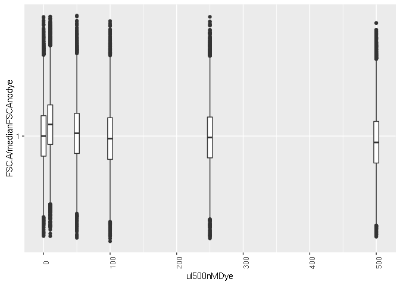

```r
medianFSCAnodye <- median(subset(gfdatar,ul500nMDye==0)$FSC.A)
ggplot(gfdatar)+
  aes(x=ul500nMDye,y=FSC.A/medianFSCAnodye,group=name)+
  geom_boxplot()+scale_y_log10()+
  theme(axis.text.x=element_text(angle=90))
```

Population composition

```r
t(apply(
  data.frame(
    aggregate(data=gfdatar,cbind(gfpPos,gfpNeg)~ul500nMDye,
      FUN=function(x){sum(x==T)}),
    aggregate(data=gfdatar,name~ul500nMDye,FUN=length)
   ),1,function(x){return(c(x[1],x[2:3]/x[5]))}))
```

```
##      ul500nMDye      gfpPos    gfpNeg
## [1,]          0 0.000000000 0.9427871
## [2,]         10 0.004918693 0.9843959
## [3,]         50 0.013689741 0.9530279
## [4,]        100 0.013608447 0.9152364
## [5,]        250 0.016003196 0.8966627
## [6,]        500 0.018019341 0.8078706
```

Step 5: Quality control

> “Great Scientist calculates in terms of the Control of the Quality of the Apparatus, not in terms of earning a living. Agriculture is inspired by the fear of hunger; study, by an interest in salary. Great Scientist is concerned about the Apparatus; not about poverty. Yet.”
> - Confucious

Scroll up to see how the gates did. Below is an example of `ggplot()`.

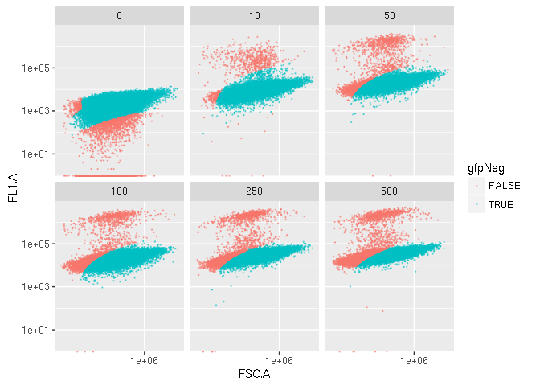

```r
ggplot(gfdatar)+
  facet_wrap(~ul500nMDye)+
  aes(x=FSC.A,y=FL1.A,col=gfpNeg)+
  geom_point(alpha=0.5,size=0.2)+
  scale_y_log10()+scale_x_log10()
```

Data transformation for visualization

> “Data can make the Transformation great; it isn’t Transformation which makes the Data great.”
> - Confucious

In order to look at QC plots the data is transformed using the logicle transform, which is a log transform for high values that transitions to a linear transformation near zero values. This is simply for visualization purposes.

the parameters w,t, and m define the transformation parameters Below, dataset 1 tranformation applied to every channel except width and time.

```r
lgcl <- logicleTransform(w = 0.5, t= 10000, m=4.5)
dataLGCLTransform <- transform(gatedFilteredDatar,'FSC.A' = lgcl(`FSC.A`), 'SSC.A' =lgcl(`SSC.A`), 'FL1.A' = lgcl(`FL1.A`), 'FL2.A' = lgcl(`FL2.A`), 'FL3.A' = lgcl(`FL3.A`), 'FL4.A' = lgcl(`FL4.A`),'FSC.H' = lgcl(`FSC.H`),'SSC.H' = lgcl(`SSC.H`),'FL1.H' = lgcl(`FL1.H`),'FL2.H' = lgcl(`FL2.H`),'FL3.H' = lgcl(`FL3.H`),'FL4.H' = lgcl(`FL4.H`))
```

Effect of time

> “Study the past if you would define the future.”
> - Confucious

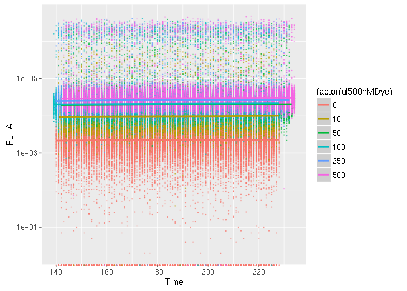

```r
ggplot(gfdatar)+
  aes(x=Time,y=FL1.A,col=factor(ul500nMDye))+
  geom_point(size=0.2,alpha=0.5)+
  stat_smooth()+scale_y_log10()
```

Two more plots

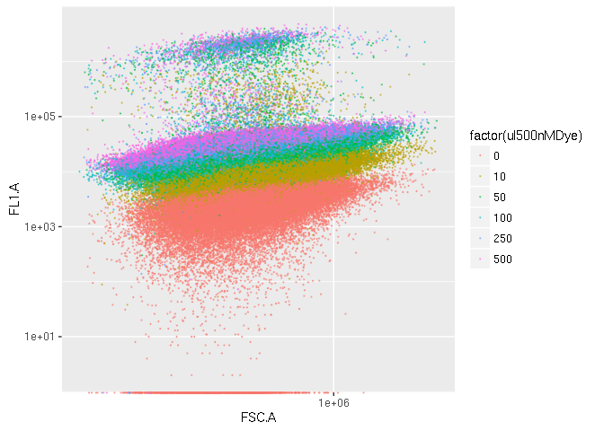

```r
ggplot(gfdatar[sample(1:nrow(gfdatar)),])+
  aes(x=FSC.A,y=FL1.A,col=factor(ul500nMDye))+
  geom_point(size=0.2,alpha=0.5)+
  scale_y_log10()+scale_x_log10()
```

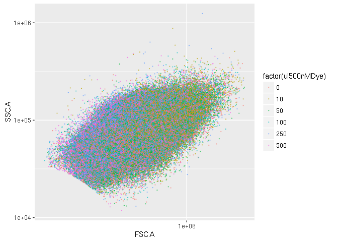

```r
ggplot(gfdatar[sample(1:nrow(gfdatar)),])+
  aes(x=FSC.A,y=SSC.A,col=factor(ul500nMDye))+
  geom_point(size=0.2,alpha=0.5)+
  scale_y_log10()+scale_x_log10()
```